# LS_Assignment_10/11

Audrene Tiakor

March 24, 2019

```r
library(readr) # CSV file I/O, e.g. the read_csv function
library(dplyr) # Heavy use of this library
library(tidyr)
library(plyr)
library(knitr)
library(datasets) # to make region col
library(agricolae)
library(caret)
library(FNN) #for knn regression
library(class)
```

### A. Clean and Prepare The Data:

1. Create column for brewery ID that is common to both datasets similar to what you did in the project, so we can merge!

```r
# Read in beer and breweries data set using _csv for more tidy output
Beers <- read_csv('Beers.csv', col_types = cols())
Breweries <- read_csv('Breweries.csv', col_types = cols())
```

2. Merge the beer and brewery data into a single dataframe.

```r
BrewPub <- merge(Beers, Breweries, by.x = "Brewery_id", by.y = "Brew_ID", all = TRUE)
# Change variable names to more meaningful title

BrewPub <- rename(BrewPub, c("Name.x"="Beer","Name.y"="Brewery",
                   "Ounces"="OZ"))
```

3. Clean the State Column…get rid of extraneous white space.

```r
trimws(BrewPub$State)
```

[output not shown]

[output cut: 171 more lines]

4. Create one dataset that has only Colorado and Texas beers and no IBU NAs…name it “beerCOTX”.

```r
#extract information for Texas from BrewPub (merged dataset)
Texas <- BrewPub[which(BrewPub$State == 'TX'),names(BrewPub) %in% c("Brewery_id","Beer","Beer_ID","ABV","IBU","Style","OZ","Brewery","City","State")] %>% na.omit()


#extract information for Texas from BrewPub (merged dataset)
Colorado <- BrewPub[which(BrewPub$State == 'CO'),names(BrewPub) %in% c("Brewery_id","Beer","Beer_ID","ABV","IBU","Style","OZ","Brewery","City","State")] %>% na.omit()


#Creating beerCOTX
beerCOTX<-rbind(Texas, Colorado)

#Check for any NA's
any(is.na(beerCOTX))
```

```
## [1] FALSE
```

5. Order beerCOTX by IBU (ascending) … this will be important later in graphing.

```r
#sorting IBU in ascending order
beerCOTX[]<-lapply(beerCOTX, as.character)
beerCOTX[order(beerCOTX$IBU),]
```

```
##      Brewery_id                                                Beer
## 460          67                                             Rye Wit
## 280          38                                        White Rascal
## 699         119                                 Valkyrie Double IPA
## 703         119                                PRO-AM (2012) (2012)
## 747         128                            Dream Crusher Double IPA
## 673         111                                    Redacted Rye IPA
## 674         111                     Elevation Triple India Pale Ale
## 676         111                             Ryeteous Rye IPA (2012)
## 1018        167                                  GUBNA Imperial IPA
## 2255        497                                     Hop Abomination
## 1267        221                                  Hemlock Double IPA
## 698         119                                    Red Cockaded Ale
## 700         119                             Red Cockaded Ale (2013)
## 1249        215                                        More Cowbell
```

[output cut: 690 more lines]

### B. Compare two competing models: External Cross Validation:

8. For this assignment we will concentrate only on the Texas data! Create a training and test set from the data (60%/40% split respectively). Print a summary of each new data frame…there should be two: TrainingTX, TestTX.

```r
#create training and test set for Texas, 60% train, 40% test
set.seed(123)
samp_size<-floor(0.60*nrow(Texas))
train_ind<-sample(seq_len(nrow(Texas)),size=samp_size)
TrainingTX<-Texas[train_ind,]
TestTX<-Texas[-train_ind,]

#summary for each TrainingTX and TestTX
summary(TrainingTX)
```

```
##    Brewery_id        Beer              Beer_ID          ABV
##  Min.   : 30.0   Length:52          Min.   :  46   Min.   :0.04000
##  1st Qu.:119.0   Class :character   1st Qu.:1562   1st Qu.:0.05100
##  Median :129.0   Mode  :character   Median :2047   Median :0.05500
##  Mean   :158.8                      Mean   :1833   Mean   :0.05988
##  3rd Qu.:215.0                      3rd Qu.:2231   3rd Qu.:0.06650
##  Max.   :427.0                      Max.   :2588   Max.   :0.09900
##       IBU            Style                 OZ          Brewery
##  Min.   :  5.00   Length:52          Min.   :12.00   Length:52
##  1st Qu.: 20.00   Class :character   1st Qu.:12.00   Class :character
##  Median : 35.50   Mode  :character   Median :12.00   Mode  :character
##  Mean   : 43.83                      Mean   :12.92
##  3rd Qu.: 64.50                      3rd Qu.:12.00
##  Max.   :118.00                      Max.   :16.00
##      City              State
##  Length:52          Length:52
##  Class :character   Class :character
##  Mode  :character   Mode  :character
##
##
##
```

```r
summary(TestTX)
```

```
##    Brewery_id        Beer              Beer_ID          ABV
##  Min.   : 30.0   Length:36          Min.   :  44   Min.   :0.04300
##  1st Qu.:119.0   Class :character   1st Qu.: 994   1st Qu.:0.05000
##  Median :128.0   Mode  :character   Median :1806   Median :0.05650
##  Mean   :163.6                      Mean   :1568   Mean   :0.06117
##  3rd Qu.:192.2                      3rd Qu.:2125   3rd Qu.:0.06900
##  Max.   :427.0                      Max.   :2600   Max.   :0.09900
##       IBU            Style                 OZ          Brewery
##  Min.   :  5.00   Length:36          Min.   :12.00   Length:36
##  1st Qu.: 21.00   Class :character   1st Qu.:12.00   Class :character
##  Median : 29.50   Mode  :character   Median :12.00   Mode  :character
##  Mean   : 35.81                      Mean   :12.67
##  3rd Qu.: 41.25                      3rd Qu.:12.00
##  Max.   :100.00                      Max.   :16.00
##      City              State
##  Length:36          Length:36
##  Class :character   Class :character
##  Mode  :character   Mode  :character
##
##
##
```

9.Using the training data, fit a KNN regressgion model to predict ABV from IBU. You should use the knnreg function in the caret package. Fit two separate models: one with k=3 and one with k=5. (This is 2 models total).

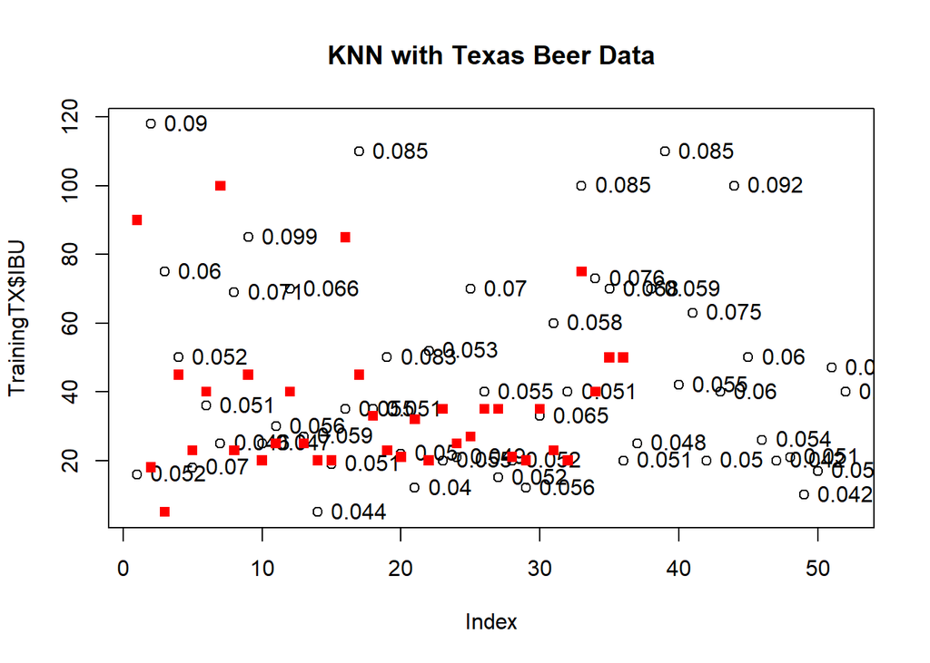

```r
#Plot of Data
plot(TrainingTX$IBU, main = "KNN with Texas Beer Data")
text(TrainingTX$IBU, labels=TrainingTX$ABV, pos=4, col="black")
points(TestTX$IBU, col="red", pch=15)
```

```r
#knn regression model for k=3
fit_3<-knnreg(ABV~IBU, data=TrainingTX, k=3)
predsTestTX.reg_3<-predict(fit_3, TestTX)
ASEholderTestTX.reg_3 = sum((predsTestTX.reg_3 - TestTX$ABV)^2)/(length(TestTX$ABV))
ASEholderTestTX.reg_3
```

```
## [1] 0.0001432295
```

```r
#knn regression model for k=5
fit_5<-knnreg(ABV~IBU, data=TrainingTX, k=5)
predsTestTX.reg_5<-predict(fit_5, TestTX)
ASEholderTestTX.reg_5 = sum((predsTestTX.reg_5 - TestTX$ABV)^2)/(length(TestTX$ABV))
ASEholderTestTX.reg_5
```

```
## [1] 0.0001389453
```

[output not shown]